# DATA 606 Data Project Proposal

Paul Perez

### Data Preparation

```r
# load data
#install.packages(c("psych", "ggplot2", "DT"))
library(psych)
library(ggplot2)
library(DT)
df <- read.csv("https://raw.githubusercontent.com/ChefPaul/R/master/d606_Project/exam_results.csv", TRUE, ",")
```

### Research question

**You should phrase your research question in a way that matches up with the scope of inference your dataset allows for.** Does a parents level of education contribute to their child’s test outcome?

### Cases

**What are the cases, and how many are there?** Each case represents a student from a random selection/generation

### Data collection

**Describe the method of data collection.** The data was found on Kaggle with an additional link for generating a new sample file. These are fictional, randomly generated records for educational purposes only.

### Type of study

**What type of study is this (observational/experiment)?** This is an observational study.

### Data Source

**If you collected the data, state self-collected. If not, provide a citation/link.** SPScientist. (2018), [Students Performance in Exams](https://www.kaggle.com/spscientist/students-performance-in-exams/metadata) Kimmons, Royce. (2012), [Understanding digital participation divides](http://roycekimmons.com/tools/generated_data/exams)

### Dependent Variable

**What is the response variable? Is it quantitative or qualitative?** The dependent variables are the 3 different test scores (math, reading, writing). These are quantitative variables.

### Independent Variable

**You should have two independent variables, one quantitative and one qualitative.** There are a few independent variables, but some more important one’s to look at are gender, parental level of education, and test preparation course. These are qualitative variables.

### Relevant summary statistics

**Provide summary statistics for each the variables. Also include appropriate visualizations related to your research question (e.g. scatter plot, boxplots, etc). This step requires the use of R, hence a code chunk is provided below. Insert more code chunks as needed.** ### Descriptive Statistics

```r
describe(df$math.score)
```

```
##    vars    n  mean    sd median trimmed   mad min max range  skew kurtosis
## X1    1 1000 66.41 15.45   66.5   66.52 15.57  21 100    79 -0.11    -0.18
##      se
## X1 0.49
```

```r
describe(df$reading.score)
```

```
##    vars    n  mean   sd median trimmed   mad min max range  skew kurtosis
## X1    1 1000 69.43 14.6     70   69.62 14.83  24 100    76 -0.16    -0.28
##      se
## X1 0.46
```

```r
describe(df$writing.score)
```

```
##    vars    n  mean    sd median trimmed   mad min max range  skew kurtosis
## X1    1 1000 68.09 15.38     69   68.34 14.83  21 100    79 -0.17     -0.3
##      se
## X1 0.49
```

### Counts for each Level of Education

```r
table(df$parental.level.of.education)
```

```
##
## associate's degree  bachelor's degree        high school
##                176                122                213
##    master's degree       some college   some high school
##                 56                241                192
```

```r
datatable(describeBy(df$math.score, group = df$parental.level.of.education, mat = TRUE), rownames = FALSE)
```

```
## This version of Shiny is designed to work with 'htmlwidgets' >= 1.5.
##     Please upgrade via install.packages('htmlwidgets').
```

| item | group1 | vars | n | mean | sd | median | trimmed | mad | min | max | range | skew | kurtosis | se |
| --- | --- | --- | --- | --- | --- | --- | --- | --- | --- | --- | --- | --- | --- | --- |
| 1 | associate's degree | 1 | 176 | 68.8181818181818 | 16.256547132627 | 70 | 69.3943661971831 | 17.7912 | 21 | 100 | 79 | -0.376027835460788 | -0.155958328920094 | 1.22538334603754 |
| 2 | bachelor's degree | 1 | 122 | 71.3032786885246 | 14.0435505295281 | 71.5 | 71.6530612244898 | 12.6021 | 32 | 100 | 68 | -0.178704337513798 | -0.253046514071807 | 1.27144332427663 |
| 3 | high school | 1 | 213 | 62.7746478873239 | 15.1519322976262 | 63 | 62.7485380116959 | 14.826 | 23 | 100 | 77 | -0.021552457099565 | -0.268112719922546 | 1.03819329424046 |
| 4 | master's degree | 1 | 56 | 73.2857142857143 | 15.0993248322437 | 72.5 | 73.0434782608696 | 17.0499 | 45 | 100 | 55 | 0.132652207591849 | -0.959074809078097 | 2.01773215335228 |
| 5 | some college | 1 | 241 | 66.2199170124481 | 14.7384622103671 | 67 | 66.2227979274611 | 14.826 | 23 | 100 | 77 | -0.084421189736304 | -0.146377614050004 | 0.949387809576617 |
| 6 | some high school | 1 | 192 | 63.3802083333333 | 15.1275977461372 | 63 | 63.3701298701299 | 13.3434 | 24 | 100 | 76 | -0.031773909297118 | 0.080395266870346 | 1.09174032886559 |

```r
datatable(describeBy(df$reading.score, group = df$parental.level.of.education, mat = TRUE), rownames = FALSE)
```

| item | group1 | vars | n | mean | sd | median | trimmed | mad | min | max | range | skew | kurtosis | se |
| --- | --- | --- | --- | --- | --- | --- | --- | --- | --- | --- | --- | --- | --- | --- |
| 1 | associate's degree | 1 | 176 | 71.7045454545455 | 14.8224995701296 | 73 | 72.1971830985916 | 16.3086 | 30 | 100 | 70 | -0.30252204483671 | -0.350578096782814 | 1.11728794384828 |
| 2 | bachelor's degree | 1 | 122 | 73.9672131147541 | 13.3441010127511 | 73.5 | 74.1224489795918 | 12.6021 | 38 | 100 | 62 | -0.13831188464532 | -0.396677855555218 | 1.20811814045615 |
| 3 | high school | 1 | 213 | 65.6009389671361 | 14.6072933147146 | 66 | 65.4853801169591 | 16.3086 | 28 | 100 | 72 | 0.023271126221224 | -0.43992596027825 | 1.00087524603816 |
| 4 | master's degree | 1 | 56 | 77.5357142857143 | 13.3946587532823 | 76 | 77.8478260869565 | 15.5673 | 36 | 100 | 64 | -0.36805988638873 | 0.146281895179092 | 1.78993656669768 |
| 5 | some college | 1 | 241 | 69.2697095435685 | 13.727021538992 | 70 | 69.4559585492228 | 13.3434 | 29 | 100 | 71 | -0.191246461986376 | -0.00297812446202 | 0.884235188508862 |
| 6 | some high school | 1 | 192 | 66.53125 | 14.6308525229987 | 66 | 66.6753246753247 | 16.3086 | 24 | 98 | 74 | -0.121292820351562 | -0.269463886816093 | 1.05589083032838 |

```r
datatable(describeBy(df$writing.score, group = df$parental.level.of.education, mat = TRUE), rownames = FALSE)
```

| item | group1 | vars | n | mean | sd | median | trimmed | mad | min | max | range | skew | kurtosis | se |
| --- | --- | --- | --- | --- | --- | --- | --- | --- | --- | --- | --- | --- | --- | --- |
| 1 | associate's degree | 1 | 176 | 70.4715909090909 | 15.6967436030617 | 71 | 71.056338028169 | 16.3086 | 28 | 100 | 72 | -0.328536562610529 | -0.29501191996598 | 1.18318656731289 |
| 2 | bachelor's degree | 1 | 122 | 73.9918032786885 | 13.0063531212519 | 73 | 74.0204081632653 | 13.3434 | 40 | 100 | 60 | -0.067532898688092 | -0.415325549474701 | 1.17753988312498 |
| 3 | high school | 1 | 213 | 63.3708920187793 | 15.8946560870337 | 65 | 63.3567251461988 | 17.7912 | 21 | 100 | 79 | -0.016527521751589 | -0.529429532899215 | 1.0890838897427 |
| 4 | master's degree | 1 | 56 | 77.2678571428571 | 14.1002786193343 | 76.5 | 77.6521739130435 | 17.7912 | 42 | 100 | 58 | -0.241666298881053 | -0.589667229543252 | 1.88422898755725 |
| 5 | some college | 1 | 241 | 68.1825726141079 | 14.1161796656914 | 69 | 68.4352331606218 | 11.8608 | 27 | 100 | 73 | -0.222850691396302 | 0.154029373041923 | 0.90930306711198 |
| 6 | some high school | 1 | 192 | 64.6145833333333 | 15.045738149878 | 64 | 64.512987012987 | 16.3086 | 28 | 100 | 72 | 0.022458021215507 | -0.425941058160244 | 1.08583262137359 |

## Histograms ### Math Scores

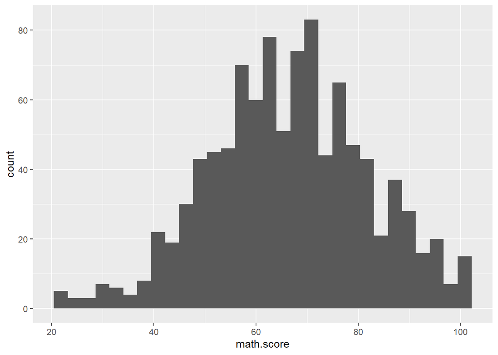

```r
ggplot(df, aes(x=math.score)) + geom_histogram()
```

### Reading Scores

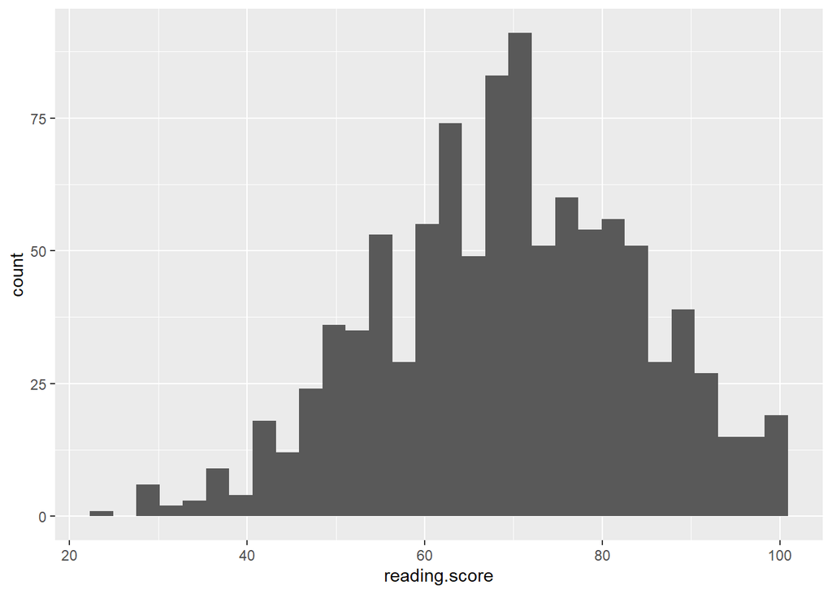

```r
ggplot(df, aes(x=reading.score)) + geom_histogram()
```

### Writing Scores

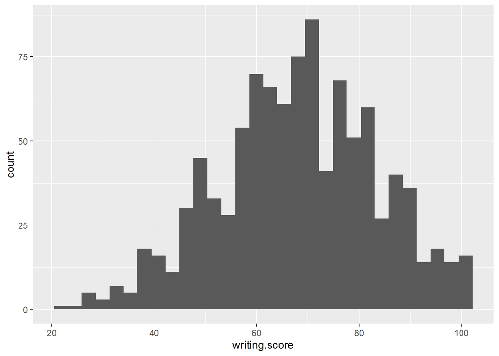

```r
ggplot(df, aes(x=writing.score)) + geom_histogram()
```

## Next Steps

Based on this intial summary of the data, it looks like there are more cuts of data to look at for a more in depth exploratory anlaysis. It will be interesting to look at other attributes such as gender, race, lunch status and test preparation to see if their are any trends.